# IODS course project

Kaisla Komulainen

# About the project

This is my Introduction to Open Data Science course project.

https://github.com/kjoanna/IODS-project

# Attitudes towards statistics associated with statistics course perfomance?

**Data and analysis**

This analysis evaluates the association of a student’s overall attitude towards statistics with their performance on a introductory statistics course among Finnish university students. Data were from the Students 2014 study (N=183). The dataset has been described in detail elsewhere (http://www.helsinki.fi/~kvehkala/JYTmooc/JYTOPKYS3-meta.txt). All analyses were conducted in an imputed dataset with no missing values. We included 166 participants who scored higher than zero on the final exam.

Linear regression analysis was used to evaluate the assocations of attitudes with course perfomance. Course performance, measured as a continuous score obtained on the final exam, was the study outcome, and attitude, measured as the mean of 10 attitudinal items reported on a 5-point Likert scale was the primary exposure. Higher values on the final attitude variable indicated more positive attitudes towards statistics. The associations of attitudes with performance were assessed first without adjustments and then adjusting for age and gender that were considered as potential confounders to the attitude-perfomance association. Linear model assumptions were evaluated graphically, by plotting residuals against the fitted values, creating QQ-plots and examining the leverage of outliers based on Cook’s distance.

**Results**

There were 110 (66%) females. The mean age in the sample was 25.5 (SD=7.8). The mean score on the final exam was 22.7 (SD=5.9). On average, participants reported a neutral attitude towards statistics (mean=3.1, SD=0.7).

More positive attitude was positively correlated with exam points (p<0.001). Gender was associated with attitudes, with male participants reporting more positive attitudes (p<0.001). Age was not correlated with attitudes (p>0.05).

In unadjusted linear regression analysis, each one unit increase on the attitudinal scale was associated with 3.5 points higher final exam score (b=3.5, 95% CI, 2.4 to 4.6 p<0.001). This estimate remained similar after adjusting for age and gender (b=3.6, 95% CI, 2.4 to 4.8), p<0.002). Both the unadjusted and adjusted model explained approximately 19% of the variance of course performance (R squared=0.19).

Regression diagnosics analyses showed that the model met the key linear regression assumptions (all plots shown below). Residuals were relatively normally distributed with a mean of zero and a constant variance across the range of fitted values. No notable outliers impacting the model with greater leverage than other observations were observed.

**Conclusion**

These data suggest a more positive attitude towards statistics is associated with better course performance among Finnish university students. The association remained after adjusting for age and gender, suggesting no strong confounding by these demographic factors.

```r
#setwd ("/Users/kjkomula/Documents/GitHub/IODS-project/data")

library(ggplot2)
library(GGally)
library(plyr)
library(dplyr)
library(knitr)
library(psych)


lrn14 <- read.table("http://s3.amazonaws.com/assets.datacamp.com/production/course_2218/datasets/learning2014.txt", sep=",", header=TRUE)
setwd ("/Users/kjkomula/Documents/GitHub/IODS-project/")
write.table(lrn14, file = "learning2014s3", sep = "\t")


# Students 2014 data
l14<-read.table("/Users/kjkomula/Documents/GitHub/IODS-project/learning2014s3", sep ="\t")
l14 <- as.data.frame(l14)

# explore the structure and dimensions of Students 2014
str(l14)
```

```
## 'data.frame':    166 obs. of  7 variables:
##  $ gender  : Factor w/ 2 levels "F","M": 1 2 1 2 2 1 2 1 2 1 ...
##  $ age     : int  53 55 49 53 49 38 50 37 37 42 ...
##  $ attitude: num  3.7 3.1 2.5 3.5 3.7 3.8 3.5 2.9 3.8 2.1 ...
##  $ deep    : num  3.58 2.92 3.5 3.5 3.67 ...
##  $ stra    : num  3.38 2.75 3.62 3.12 3.62 ...
##  $ surf    : num  2.58 3.17 2.25 2.25 2.83 ...
##  $ points  : int  25 12 24 10 22 21 21 31 24 26 ...
```

```r
dim(l14)
```

```
## [1] 166   7
```

```r
myvars <- list(l14$age,l14$attitude,l14$points)
myvars[1]
```

```
## [[1]]
##   [1] 53 55 49 53 49 38 50 37 37 42 37 34 34 34 35 33 32 44 29 30 27 29 31
##  [24] 37 26 26 30 33 33 28 26 27 25 31 20 39 38 24 26 25 30 25 30 48 24 40
##  [47] 25 23 25 23 27 25 23 23 23 45 22 23 21 21 21 21 26 25 26 21 23 22 22
##  [70] 22 23 22 23 24 22 23 22 20 22 21 22 23 21 22 29 29 21 28 21 30 21 23
##  [93] 21 21 20 22 21 21 20 22 20 20 24 20 19 21 21 22 25 21 22 25 20 24 20
## [116] 21 20 20 31 20 22 22 21 22 21 21 21 21 20 21 25 21 24 20 21 20 20 18
## [139] 21 19 21 20 21 20 21 20 18 22 22 24 19 20 20 17 19 20 20 20 20 19 19
## [162] 22 35 18 19 21
```

```r
lapply(myvars, mean)
```

```
## [[1]]
## [1] 25.51205
##
## [[2]]
## [1] 3.142771
##
## [[3]]
## [1] 22.71687
```

```r
lapply(myvars, sd)
```

```
## [[1]]
## [1] 7.766078
##
## [[2]]
## [1] 0.7299079
##
## [[3]]
## [1] 5.894884
```

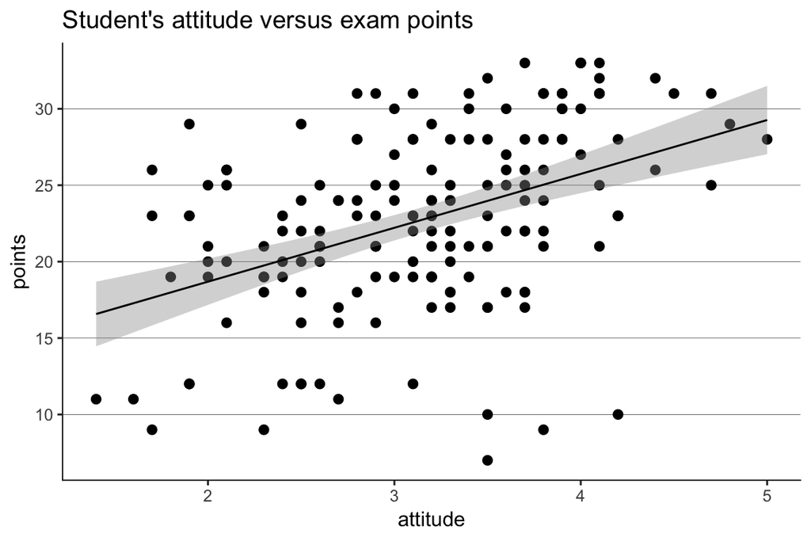

```r
# plotting attitude vs points
p1 <- ggplot(l14, aes(x = attitude, y = points)) + geom_point(size=2, shape=21, fill="black")+ geom_smooth(method="lm", colour="black", size=0.5)+ ggtitle("Student's attitude versus exam points")+ theme(legend.key = element_rect(fill = "white"),
  legend.background = element_rect(fill = "white"),
  legend.position = c(0.14, 0.80),
  panel.grid.major.x = element_blank() ,
  panel.grid.major.y = element_line( size=.1, color="black" ),
  panel.background = element_rect(fill = "white"),
  axis.line.x = element_line(color="black", size = 0.3),
  axis.line.y = element_line(color="black", size = 0.3))
p1
```

[output not shown]

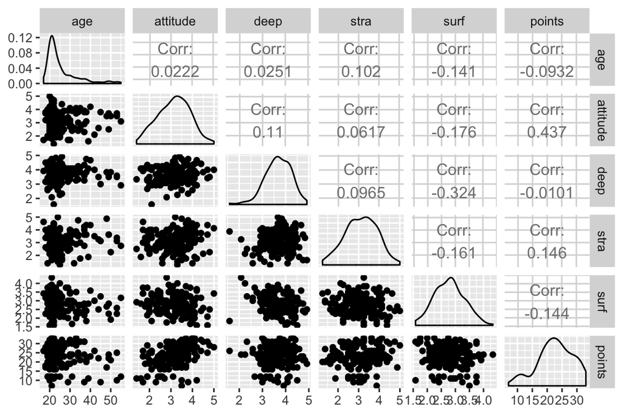

```r
# ggpairs
ggpairs(l14[-1], lower = list(combo = wrap("facethist", bins = 20)))
```

```r
#correlations
m1 <- corr.test(l14[-1], adjust="none")
m1$r
```

```
##                  age    attitude        deep        stra       surf
## age       1.00000000  0.02220071  0.02507804  0.10244409 -0.1414052
## attitude  0.02220071  1.00000000  0.11024302  0.06174177 -0.1755422
## deep      0.02507804  0.11024302  1.00000000  0.09650255 -0.3238020
## stra      0.10244409  0.06174177  0.09650255  1.00000000 -0.1609729
## surf     -0.14140516 -0.17554218 -0.32380198 -0.16097287  1.0000000
## points   -0.09319032  0.43652453 -0.01014849  0.14612247 -0.1443564
##               points
## age      -0.09319032
## attitude  0.43652453
## deep     -0.01014849
## stra      0.14612247
## surf     -0.14435642
## points    1.00000000
```

```r
m1$p
```

```
##                 age     attitude         deep       stra         surf
## age      0.00000000 7.764796e-01 7.484250e-01 0.18905345 6.917828e-02
## attitude 0.77647958 0.000000e+00 1.573728e-01 0.42939325 2.368454e-02
## deep     0.74842496 1.573728e-01 0.000000e+00 0.21614569 2.084937e-05
## stra     0.18905345 4.293933e-01 2.161457e-01 0.00000000 3.827945e-02
## surf     0.06917828 2.368454e-02 2.084937e-05 0.03827945 0.000000e+00
## points   0.23239925 4.118908e-09 8.967488e-01 0.06030923 6.351350e-02
##                points
## age      2.323992e-01
## attitude 4.118908e-09
## deep     8.967488e-01
## stra     6.030923e-02
## surf     6.351350e-02
## points   0.000000e+00
```

```r
# association of gender with attitudes
summary(model.conf <- lm(attitude ~ gender, data=l14))
```

```
##
## Call:
## lm(formula = attitude ~ gender, data = l14)
##
## Residuals:
##      Min       1Q   Median       3Q      Max
## -1.74286 -0.49000 -0.04286  0.51000  2.01000
##
## Coefficients:
##             Estimate Std. Error t value Pr(>|t|)
## (Intercept)  2.99000    0.06672  44.817  < 2e-16 ***
## genderM      0.45286    0.11487   3.943 0.000119 ***
## ---
## Signif. codes:  0 '***' 0.001 '**' 0.01 '*' 0.05 '.' 0.1 ' ' 1
##
## Residual standard error: 0.6997 on 164 degrees of freedom
## Multiple R-squared:  0.08657,    Adjusted R-squared:  0.081
## F-statistic: 15.54 on 1 and 164 DF,  p-value: 0.0001192
```

```r
# association of attitude with points
# unadjusted
summary(model.unadj <- lm(points ~ attitude, data=l14))
```

```
##
## Call:
## lm(formula = points ~ attitude, data = l14)
##
## Residuals:
##      Min       1Q   Median       3Q      Max
## -16.9763  -3.2119   0.4339   4.1534  10.6645
##
## Coefficients:
##             Estimate Std. Error t value Pr(>|t|)
## (Intercept)  11.6372     1.8303   6.358 1.95e-09 ***
## attitude      3.5255     0.5674   6.214 4.12e-09 ***
## ---
## Signif. codes:  0 '***' 0.001 '**' 0.01 '*' 0.05 '.' 0.1 ' ' 1
##
## Residual standard error: 5.32 on 164 degrees of freedom
## Multiple R-squared:  0.1906, Adjusted R-squared:  0.1856
## F-statistic: 38.61 on 1 and 164 DF,  p-value: 4.119e-09
```

```r
# adjusted for age and gender
summary(model.adj <- lm(points ~ age + gender + attitude, data=l14))
```

```
##
## Call:
## lm(formula = points ~ age + gender + attitude, data = l14)
##
## Residuals:
##      Min       1Q   Median       3Q      Max
## -17.4590  -3.3221   0.2186   4.0247  10.4632
##
## Coefficients:
##             Estimate Std. Error t value Pr(>|t|)
## (Intercept) 13.42910    2.29043   5.863 2.48e-08 ***
## age         -0.07586    0.05367  -1.414    0.159
## genderM     -0.33054    0.91934  -0.360    0.720
## attitude     3.60657    0.59322   6.080 8.34e-09 ***
## ---
## Signif. codes:  0 '***' 0.001 '**' 0.01 '*' 0.05 '.' 0.1 ' ' 1
##
## Residual standard error: 5.315 on 162 degrees of freedom
## Multiple R-squared:  0.2018, Adjusted R-squared:  0.187
## F-statistic: 13.65 on 3 and 162 DF,  p-value: 5.536e-08
```

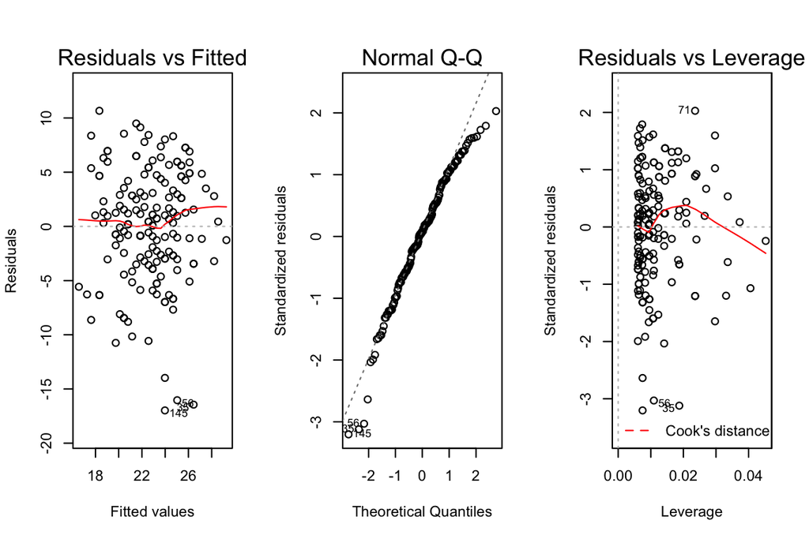

```r
# residual plots for both the unadjusted and adjusted models
par(mfrow=c(1,3))
plot(model.unadj, which = c(1:2, 5))
```

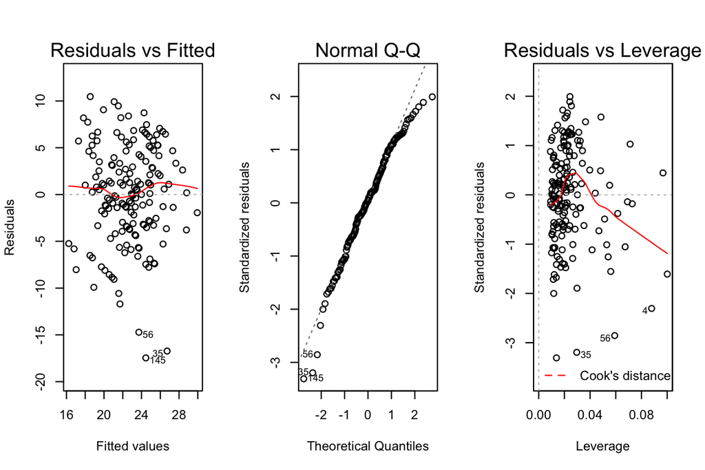

```r
plot(model.adj, which = c(1:2, 5))
```

rmarkdown::render(“/Users/kjkomula/Documents/GitHub/IODS-project/chapter2_revrev.Rmd”, output_format = “html_document”)

rmarkdown::render(“/Users/kjkomula/Documents/GitHub/IODS-project/chapter3.Rmd”, output_format = “html_document”)

# Going out with friends or being in a relationship - associations with student alcohol use?

This analysis examines whether going out with friends or relationship status are associated with alcohol consumption among Portugese students (n=382). We test the hypothesis that going out more frequently and being single are assocated with high (vs low) alcohol consumption, compared to staying in and being in a relationship.

Alcohol consumption was measured as the self-reported average of weekly alcohol use on a scale ranging from 1 to 5 (higher numbers indicate heavier use). We treated alcohol use as a dichotomous outcome variable (high vs low, >2 vs ≤2). Students also reported the frequency of going out with friends on a 5-point scale and their relationship status (yes/no). We first examined the unadjusted associations of going out and relationship status with alcohol use graphically in boxplots and bar graphs. The associations were then assessed in a mutually adjusted logistic regression analysis, additinally adjusting for sex and age as other potential confounders.

The distributions of the variables included in the analysis are presented in histograms below. Mean age in the sample was 16.6 (SD, 1.2) and most participants were 15 to 19 years old. There were 198 (52%) females. The distribution of alcohol use reported on the 5-point scale was heavily right skewed, with most participants (70%) reporting low alcohol use. There was no difference in the frequency of going out with friends between those in a relationship vs those who were single (p=0.82).

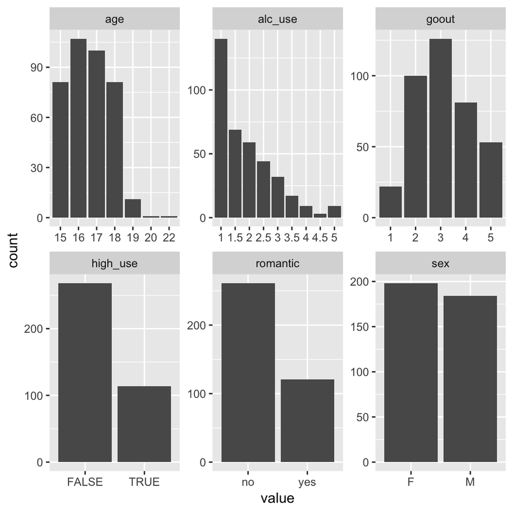

First, the unadjusted associations of going out with friends and relationship status with alcohol use were examined graphically. The plots presented below suggest high alcohol consumption is associated with higher frequency going out with peers. In contrast, no clear pattern of association is observed between alcohol consumption and relationship status.

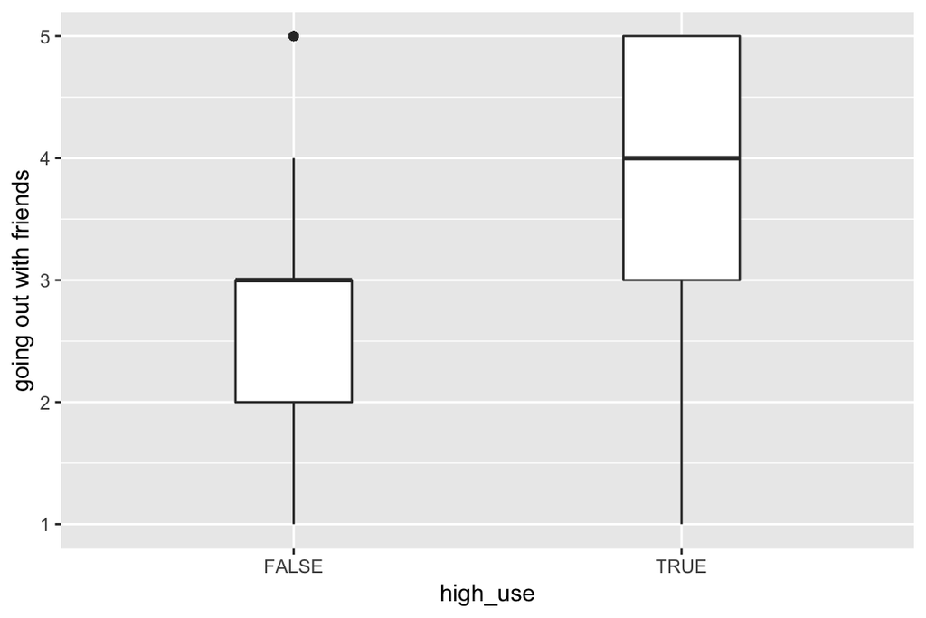

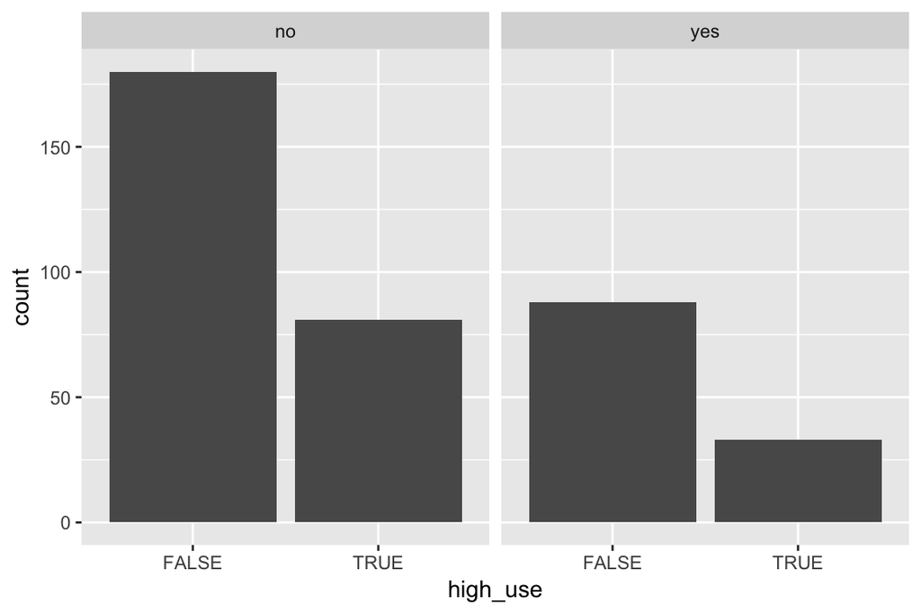

In the logistic regression analysis, students who went out with friends more often were indeed more likely to be high alcohol users (adjusted OR=2.1, 95% CI 1.7, 2.7). However, as suggested by the bar chart above, relationship status was not associated with high alcohol use (OR=0.8, 95% CI, 0.5, 1.4, p=0.42). Additionally, we observed that the odds of high alcohol use were 2.4-fold among men compared to women (OR=2.4, 95% CI, 1.5, 3.9), but did not differ according to age.(OR=1.1, 95% CI, 0.9, 1.4, p=0.19)

**Model predicted vs actual values**

| Table | model says NO | model says YES |
| --- | --- | --- |
| high use is NO | 252 | 16 |
| high use is YES | 66 | 48 |

```r
#setwd ("/Users/kjkomula/Documents/GitHub/IODS-project/data")

library(dplyr)
library(tidyr)
library(ggplot2)
library(psych)

alc <- read.table("/Users/kjkomula/Documents/GitHub/IODS-project/alc", sep="\t", header=TRUE)

colnames(alc)
```

```
##  [1] "school"      "sex"         "age"         "address"     "famsize"
##  [6] "Pstatus"     "Medu"        "Fedu"        "Mjob"        "Fjob"
## [11] "reason"      "nursery"     "internet"    "guardian"    "traveltime"
## [16] "studytime"   "failures"    "schoolsup"   "famsup"      "paid"
## [21] "activities"  "higher"      "romantic"    "famrel"      "freetime"
## [26] "goout"       "Dalc"        "Walc"        "health"      "absences"
## [31] "G1"          "G2"          "G3"          "alc_use"     "high_use"
## [36] "probability" "prediction"
```

```r
# describing things
describe(alc$age)
```

```
##    vars   n  mean   sd median trimmed  mad min max range skew kurtosis
## X1    1 382 16.59 1.17     17   16.55 1.48  15  22     7  0.4     0.06
##      se
## X1 0.06
```

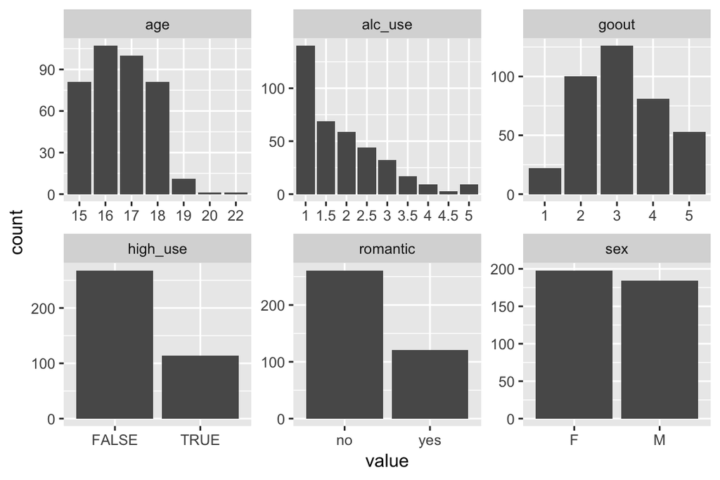

```r
# histograms of all variables
newalc <- alc[c("alc_use", "high_use", "sex", "age", "romantic", "goout")]
gather(newalc) %>% ggplot(aes(value)) + facet_wrap("key", scales = "free") + geom_bar()
```

```r
# associations of relationship with going out
alc %>% group_by(romantic) %>% summarise(mean(goout))
```

```
##   mean(goout)
## 1    3.112565
```

```r
t.test(goout ~romantic, data=alc)
```

```
##
##  Welch Two Sample t-test
##
## data:  goout by romantic
## t = -0.23235, df = 230.28, p-value = 0.8165
## alternative hypothesis: true difference in means is not equal to 0
## 95 percent confidence interval:
##  -0.2728659  0.2152996
## sample estimates:
##  mean in group no mean in group yes
##          3.103448          3.132231
```

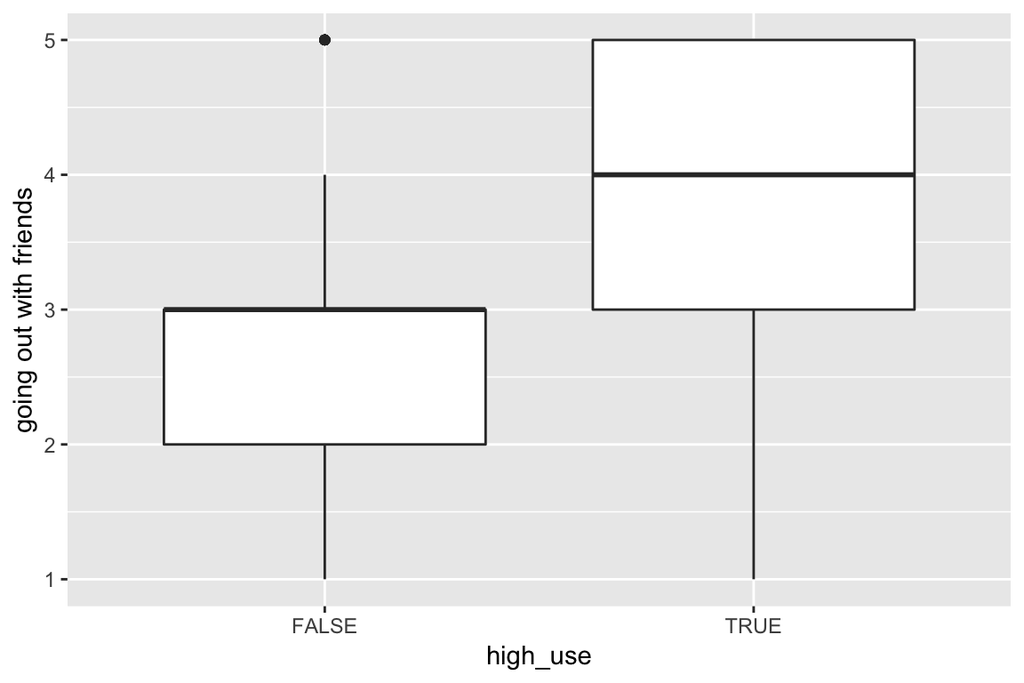

```r
# boxplot going out & alcohol use
g1 <- ggplot(alc, aes(x = high_use, y = goout))
g1 + geom_boxplot() + ylab("going out with friends")
```

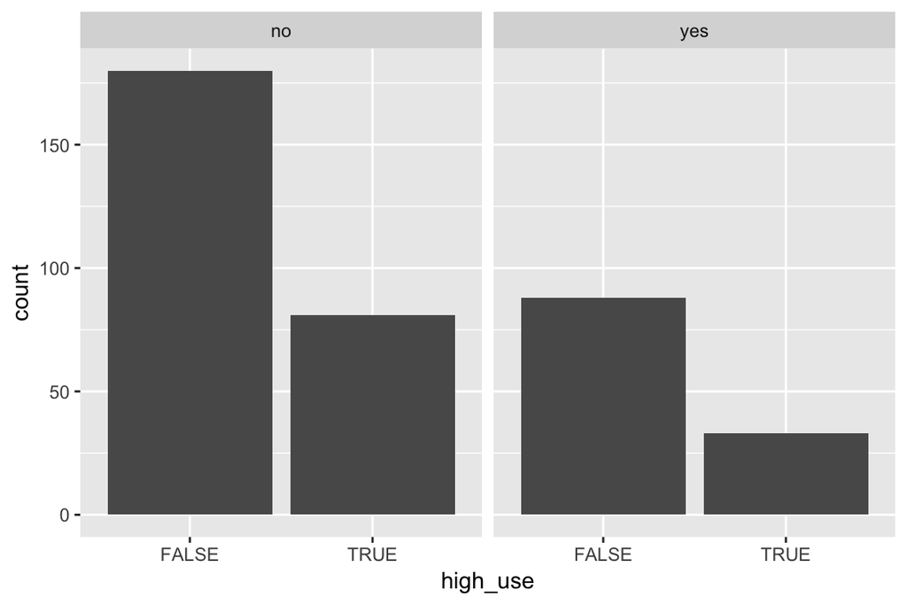

```r
# barchart relatonship & alcohol use
g2 <- ggplot(alc, aes(high_use))
g2 + facet_wrap("romantic") + geom_bar()
```

```r
# logistic regression
m <- glm(high_use ~ sex + age + romantic + goout, data = alc, family = "binomial")
OR <- coef(m) %>% exp
CI <- confint(m) %>% exp
cbind(OR, CI)
```

```
##                    OR        2.5 %     97.5 %
## (Intercept) 0.0024775 6.911961e-05 0.07771529
## sexM        2.3918378 1.478736e+00 3.91283974
## age         1.1495911 9.338229e-01 1.41914222
## romanticyes 0.8037401 4.696478e-01 1.35609165
## goout       2.0989715 1.671812e+00 2.66898575
```

```r
## predictive power
probabilities <- predict(m, type = "response")
alc <- mutate(alc, probability = probabilities)
alc <- mutate(alc, prediction = probability > 0.5)
select(alc, failures, absences, sex, high_use, probability, prediction) %>% tail(10)
```

```
##     failures absences sex high_use probability prediction
## 373        1        0   M    FALSE  0.26956539      FALSE
## 374        1        7   M     TRUE  0.40256532      FALSE
## 375        0        1   F    FALSE  0.21979703      FALSE
## 376        0        6   F    FALSE  0.18462387      FALSE
## 377        1        2   F    FALSE  0.13367013      FALSE
## 378        0        2   F    FALSE  0.37158990      FALSE
## 379        2        2   F    FALSE  0.11833454      FALSE
## 380        0        3   F    FALSE  0.06010108      FALSE
## 381        0        4   M     TRUE  0.72085387       TRUE
## 382        0        2   M     TRUE  0.13265530      FALSE
```

```r
table(high_use = alc$high_use, prediction = alc$prediction)
```

```
##         prediction
## high_use FALSE TRUE
##    FALSE   252   16
##    TRUE     66   48
```

rmarkdown::render(“/Users/kjkomula/Documents/GitHub/IODS-project/index.Rmd”, output_format = “html_document”)